# Lasso Regression

Lets learn how to run a lasso regression.

### Import libraries

```r
library(tidyverse) # data manipulation
library(caret) # machine learning
library(glmnet) # lasso regression
```

### Load the dataset

I’m going to point my working directory to where my data files are located with `setwd()`. Then I’m going to view all the columns that are in the dataset.

[output not shown]

```
 [1] "ID"        "BIO_SEX"   "HISPANIC"  "WHITE"     "BLACK"     "NAMERICAN" "ASIAN"
 [8] "AGE"       "TREG1"     "ALCEVR1"   "ALCPROBS1" "MAREVER1"  "COCEVER1"  "INHEVER1"
[15] "CIGAVAIL"  "DEP1"      "ESTEEM1"   "VIOL1"     "PASSIST"   "DEVIANT1"  "SCHCONN1"
[22] "GPA1"      "EXPEL1"    "FAMCONCT"  "PARACTV"   "PARPRES"
```

We will do some data management by turning `BIO_SEX` into `MALE` and making sure `SCHONN1` is numeric.

Next, I will pick out the variables that I need. The variable names of the predictors we will use in our lasso regression are in `pred_vars`. The variable that we are trying to predict is `SCHCONN1` which is in `dep_vars`. Lastly, we create a clean data frame that drops all NA’s

```r
pred_vars <- c('MALE','HISPANIC','WHITE','BLACK','NAMERICAN','ASIAN','AGE','ALCEVR1',
    'ALCPROBS1','MAREVER1','COCEVER1','INHEVER1','CIGAVAIL','DEP1','ESTEEM1',
    'VIOL1','PASSIST','DEVIANT1','GPA1','EXPEL1','FAMCONCT','PARACTV','PARPRES'
)
dep_vars <- c("SCHCONN1")
df <- df %>%
  mutate(MALE = ifelse(BIO_SEX == 1, 1, 0),
         SCHCONN1 = as.numeric(SCHCONN1)) %>%
  select(pred_vars, dep_vars) %>%
  na.omit()

head(df)
```

| MALE | HISPANIC | WHITE | BLACK | NAMERICAN | ASIAN | AGE | ALCEVR1 | ALCPROBS1 | MAREVER1 | COCEVER1 | INHEVER1 | CIGAVAIL | DEP1 | ESTEEM1 | VIOL1 | PASSIST | DEVIANT1 | GPA1 | EXPEL1 | FAMCONCT | PARACTV | PARPRES | SCHCONN1 |
| --- | --- | --- | --- | --- | --- | --- | --- | --- | --- | --- | --- | --- | --- | --- | --- | --- | --- | --- | --- | --- | --- | --- | --- |
| 0 | 0 | 0 | 1 | 0 | 0 | 19.42740 | 1 | 1 | 0 | 0 | 0 | 1 | 17 | 35 | 1 | 0 | 5 | 2.333333 | 0 | 23.3 | 9 | 15 | 22 |
| 1 | 0 | 0 | 1 | 0 | 0 | 20.43014 | 0 | 0 | 1 | 1 | 1 | 1 | 19 | 47 | 4 | 1 | 4 | 2.000000 | 0 | 18.7 | 6 | 14 | 19 |
| 1 | 0 | 0 | 1 | 0 | 0 | 14.50959 | 0 | 0 | 0 | 0 | 0 | 0 | 8 | 41 | 3 | 0 | 0 | 2.666667 | 0 | 23.7 | 3 | 13 | 27 |
| 1 | 0 | 0 | 1 | 0 | 0 | 13.67671 | 0 | 0 | 0 | 0 | 0 | 1 | 4 | 42 | 5 | 0 | 7 | 2.500000 | 0 | 24.7 | 6 | 13 | 18 |
| 1 | 0 | 1 | 0 | 0 | 0 | 15.17808 | 1 | 0 | 1 | 0 | 0 | 1 | 4 | 40 | 8 | 1 | 6 | 1.500000 | 0 | 22.3 | 10 | 14 | 20 |
| 1 | 0 | 0 | 1 | 0 | 0 | 14.67397 | 1 | 0 | 0 | 0 | 0 | 1 | 6 | 39 | 0 | 0 | 5 | 2.250000 | 0 | 19.0 | 8 | 15 | 24 |

### Center and scale

In lasso regression, the penalty term is not fair if the predictive variables are not on the same scale, meaning that not all the predictors get the same penalty. So I will standardize all the predictors to have a mean equal to zero and a standard deviation equal to one, including my binary predictors, which will put them all on the same scale.

Lets create `my_center_scale()` that transforms the variable to have a mean of zero and a standard deviation of one, thus putting all the predictors on the same scale.

```r
my_center_scale <- function(var, seed = 1234){
  set.seed(seed)
  centered <- var - mean(var)
  scaled <- centered / sd(var)

  return(scaled)
}

# Test if our function works
df$GPA1[1:20]
```

```
 [1] 2.333333 2.000000 2.666667 2.500000 1.500000 2.250000 2.500000 3.250000 2.000000
[10] 2.250000 3.000000 3.750000 2.250000 4.000000 3.500000 2.750000 1.750000 3.500000
[19] 1.000000 3.000000
```

```r
gpa1_scaled <- my_center_scale(df$GPA1[1:20])
gpa1_scaled
```

```
 [1] -0.3289961 -0.7604654  0.1024745 -0.1132608 -1.4076700 -0.4368631 -0.1132608
 [8]  0.8575461 -0.7604654 -0.4368631  0.5339438  1.5047507 -0.4368631  1.8283530
[15]  1.1811484  0.2103415 -1.0840677  1.1811484 -2.0548746  0.5339438
```

```r
mean(gpa1_scaled)
```

```
[1] 1.159012e-16
```

```r
sd(gpa1_scaled)
```

```
[1] 1
```

Now lets apply our function to all our predictors.

```r
X <- df %>% select(-SCHCONN1)
y <- df$SCHCONN1

X <- map_df(X, my_center_scale)
head(X)
```

| MALE | HISPANIC | WHITE | BLACK | NAMERICAN | ASIAN | AGE | ALCEVR1 | ALCPROBS1 | MAREVER1 | COCEVER1 | INHEVER1 | CIGAVAIL | DEP1 | ESTEEM1 | VIOL1 | PASSIST | DEVIANT1 | GPA1 | EXPEL1 | FAMCONCT | PARACTV | PARPRES |
| --- | --- | --- | --- | --- | --- | --- | --- | --- | --- | --- | --- | --- | --- | --- | --- | --- | --- | --- | --- | --- | --- | --- |
| -0.9587816 | -0.3533409 | -1.4688664 | 1.798980 | -0.1939936 | -0.2052375 | 1.8904775 | 0.9466777 | 0.7050223 | -0.5651749 | -0.1859687 | -0.2657901 | 1.5264052 | 1.28724567 | -1.104461147 | -0.2389420 | -0.337891 | 0.6673296 | -0.6257408 | -0.2046587 | 0.2792054 | 0.80632177 | 0.7679862 |
| 1.0427625 | -0.3533409 | -1.4688664 | 1.798980 | -0.1939936 | -0.2052375 | 2.5363781 | -1.0560949 | -0.4124637 | 1.7689771 | 5.3760747 | 3.7615456 | 1.5264052 | 1.59154303 | 1.123530863 | 0.9172780 | 2.958888 | 0.3836339 | -1.0584561 | -0.2046587 | -1.4800027 | -0.08657048 | 0.2890023 |
| 1.0427625 | -0.3533409 | -1.4688664 | 1.798980 | -0.1939936 | -0.2052375 | -1.2772578 | -1.0560949 | -0.4124637 | -0.5651749 | -0.1859687 | -0.2657901 | -0.6549909 | -0.08209246 | 0.009534858 | 0.5318713 | -0.337891 | -0.7511488 | -0.1930242 | -0.2046587 | 0.4321800 | -0.97946274 | -0.1899816 |
| 1.0427625 | -0.3533409 | -1.4688664 | 1.798980 | -0.1939936 | -0.2052375 | -1.8137435 | -1.0560949 | -0.4124637 | -0.5651749 | -0.1859687 | -0.2657901 | 1.5264052 | -0.69068718 | 0.195200859 | 1.3026847 | -0.337891 | 1.2347209 | -0.4093825 | -0.2046587 | 0.8146166 | -0.08657048 | -0.1899816 |
| 1.0427625 | -0.3533409 | 0.6806483 | -0.555749 | -0.1939936 | -0.2052375 | -0.8466576 | 0.9466777 | -0.4124637 | 1.7689771 | -0.1859687 | -0.2657901 | 1.5264052 | -0.69068718 | -0.176131143 | 2.4589048 | 2.958888 | 0.9510253 | -1.7075296 | -0.2046587 | -0.1032311 | 1.10395252 | 0.2890023 |
| 1.0427625 | -0.3533409 | -1.4688664 | 1.798980 | -0.1939936 | -0.2052375 | -1.1713722 | 0.9466777 | -0.4124637 | -0.5651749 | -0.1859687 | -0.2657901 | 1.5264052 | -0.38638982 | -0.361797144 | -0.6243487 | -0.337891 | 0.6673296 | -0.7339193 | -0.2046587 | -1.3652717 | 0.50869102 | 0.7679862 |

### Split into train and test

I will split my data into a training and testing set. The size ratio will be 60% for the training sample and 40% for the test sample, indicated by `p = 0.6` in `createDataPartition()`.

```r
set.seed(1234)
trainIndex <- createDataPartition(df$SCHCONN1, p = 0.6, list = FALSE, times = 1)

X_train <- as.matrix(X[trainIndex, ]) # glmnet() expects a matrix input
X_test <- as.matrix(X[-trainIndex, ])
y_train <- y[trainIndex]
y_test <- y[-trainIndex]
```

Here I request the shape of these predictor and target training and test samples. The training sample has 2747 observations or rows, 60% of our original sample, and 23 explanatory variables. The test sample has 1829 observations or rows. 40% of the original sample. And again 23 explanatory variables or columns.

```r
dim(X_train)
```

```
[1] 2747   23
```

```r
dim(X_test)
```

```
[1] 1829   23
```

```r
length(y_train)
```

```
[1] 2747
```

```r
length(y_test)
```

```
[1] 1829
```

### Build model on train data

Once training and testing data sets have been created, we train our classifier with `glmnet()`. We input the `X_train` dataset, pass the dependent variable `y_train`

```r
# alpha = 1 is lasso penalty
regressor <- glmnet(X_train, y_train, family = "gaussian", alpha = 1)
```

### Plot coefficient progression

We can also create some plots so we can visualize some of the results. For example, we can plot the progression of the regression coefficients through the model selection process.

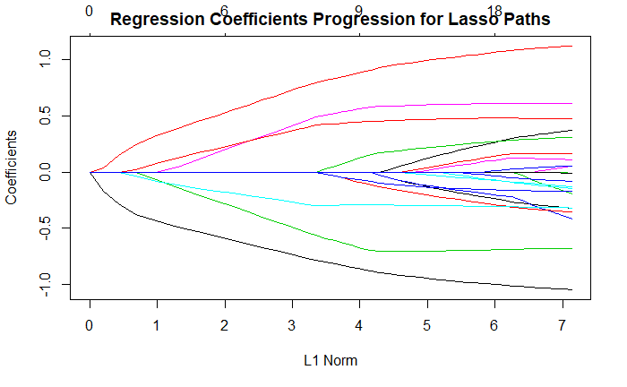

```r
plot(regressor, main = "Regression Coefficients Progression for Lasso Paths")
```

Predictors with regression coefficients that do not have a value of zero are included in the selected model. Predictors with regression coefficients equal to zero means that the coefficients for those variables had shrunk to zero after applying the LASSO regression penalty, and were subsequently removed from the model.